# Notebook

```python
import csv
import seaborn as sns
import numpy as np
import matplotlib.pyplot as plt
import pandas as ps
import datetime
```

```python
rkd = ps.read_csv('C:\\Users\\Brett\\Documents\\Data\\riverkeeper_data_2013.csv')
```

```python
rkd['Date'] = ps.Series([ps.to_datetime(x) for x in rkd['Date']])
```

Converting anything that is 'less than' or 'greater than' for the Entero Data to just that number. (i.e. <10 becomes 10)

```python
for i in range(len(rkd['EnteroCount'])):
    if not rkd['EnteroCount'][i].isdigit():
        rkd['EnteroCount'][i] = rkd['EnteroCount'][i][1:]
```

```python
rkd['EnteroCount'] = rkd['EnteroCount'].convert_objects(convert_numeric=True)
```

# 1

First let's get a feel for the data: (as per the class examples)

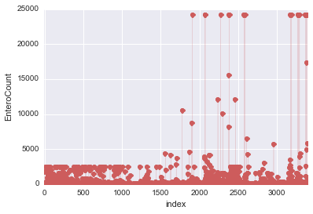

```python
%matplotlib inline
rkd['unit'] = 'Entero Count'
sns.tsplot(rkd.reset_index(),
           time="index",
           unit="unit",
           value="EnteroCount",
           color="indianred",
           interpolate=False)
```

We can see a pretty clear ceiling at 25000, but also a cutaway at 2500--these were generated by how I cleaned the data (removing the greater than/less than signs) but they still give us a good estimation of how the data looks. Let's try a boxplot by site

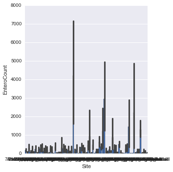

```python
sns.factorplot(x='Site', y='EnteroCount', data=rkd, kind='bar')
```

While the tet is completely useless, we can clearly see that the ranges are very large (judging by the hugh grey bars that show the quantiles) but that there are still some sites with significantly higher Enterocounts. Let's trying something more useful, like graphing those sites that average more than a thousand in the Enterocount (and would thus be reliably bad places for a swim).

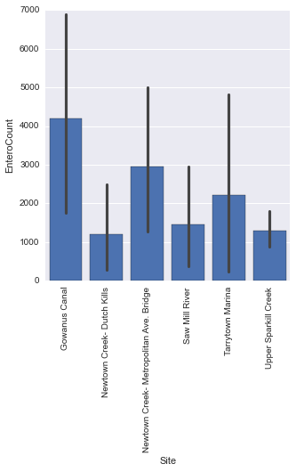

```python
bysite = rkd.groupby('Site')
bysiteHigh = bysite.filter(lambda x: x['EnteroCount'].mean() > 1000)
sns.factorplot(x='Site', y='EnteroCount', data=bysiteHigh, kind='bar')
plt.xticks(rotation=90)
```

```python
bysiteHigh.groupby('Site').mean()
```

| Site | EnteroCount | FourDayRainTotal | SampleCount |
| --- | --- | --- | --- |
| Gowanus Canal | 4206.837838 | 0.816216 | 37 |
| Newtown Creek- Dutch Kills | 1205.087719 | 0.852632 | 57 |
| Newtown Creek- Metropolitan Ave. Bridge | 2953.684211 | 0.852632 | 57 |
| Saw Mill River | 1455.760000 | 0.742000 | 50 |
| Tarrytown Marina | 2205.666667 | 0.814815 | 27 |
| Upper Sparkill Creek | 1296.072727 | 0.526061 | 165 |

We can also choose not to swim by finding all the locations that had very high levels in any sample (as it may be badly polluted on a given day, but low on others--still likely not worth the risk). We can also see that some bodies of water are only affected in certain parts (which is rather unsurprising, as those upstream of a sewage runoff would not be effected by the downstream sewage flow).

```python
bysiteMax = bysite.max()
bysiteMax.query('EnteroCount >= 24196')
```

| Site | Date | EnteroCount | FourDayRainTotal | SampleCount | unit |
| --- | --- | --- | --- | --- | --- |
| Gowanus Canal | 2013-10-16 | 24196 | 8.5 | 37 | Entero Count |
| Kingsland Pt. Park- Pocantico River | 2013-10-17 | 24196 | 4.8 | 42 | Entero Count |
| Newtown Creek- Dutch Kills | 2013-10-16 | 24196 | 8.5 | 57 | Entero Count |
| Newtown Creek- Metropolitan Ave. Bridge | 2013-10-16 | 24196 | 8.5 | 57 | Entero Count |
| Orangetown STP Outfall | 2013-10-17 | 24196 | 8.5 | 57 | Entero Count |
| Saw Mill River | 2013-10-16 | 24196 | 8.5 | 50 | Entero Count |
| Tarrytown Marina | 2013-10-17 | 24196 | 5.4 | 27 | Entero Count |
| Upper Sparkill Creek | 2012-12-10 | 24196 | 4.8 | 165 | Entero Count |

Now that we've seen some of the worst, let's take a look at the sites that would be pretty safe to swim at (judging by the Entero count).

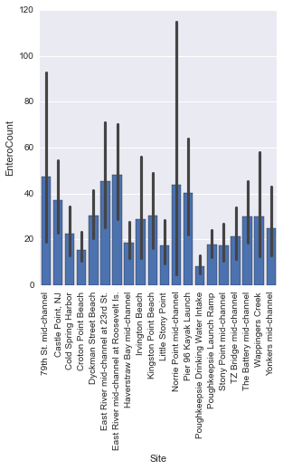

```python
bysiteLow = bysite.filter(lambda x: x['EnteroCount'].mean() < 50)
sns.factorplot(x='Site', y='EnteroCount', data=bysiteLow, kind='bar')
plt.xticks(rotation=90)
```

So we have quite a few to choose from, but we might want to avoid some that have high quantiles (such as Norrie Point mid-channel and 79th street, mid-channel). $$$$ We know that we converted those that were <1 to just one, and we can evaluate those here:

```python
bysiteMin = bysite.min()
bysiteMin.query('EnteroCount <= 1')
```

| Site | Date | EnteroCount | FourDayRainTotal | SampleCount | unit |
| --- | --- | --- | --- | --- | --- |
| 79th St. mid-channel | 2006-09-26 | 1 | 0 | 49 | Entero Count |
| Beacon Harbor | 2008-05-21 | 1 | 0 | 38 | Entero Count |
| Bethlehem Launch Ramp | 2008-05-22 | 1 | 0 | 36 | Entero Count |
| Castleton | 2008-06-19 | 1 | 0 | 35 | Entero Count |
| Catskill Creek- East End | 2008-05-22 | 1 | 0 | 42 | Entero Count |
| Catskill Creek- First Bridge | 2008-05-22 | 0 | 0 | 38 | Entero Count |
| Catskill Launch Ramp | 2008-05-22 | 1 | 0 | 37 | Entero Count |
| Coeymans Landing | 2008-05-22 | 1 | 0 | 36 | Entero Count |
| Cold Spring Harbor | 2008-06-17 | 1 | 0 | 35 | Entero Count |
| Coxsackie Waterfront Park | 2008-06-18 | 1 | 0 | 35 | Entero Count |
| East River mid-channel at 23rd St. | 2007-04-18 | 1 | 0 | 50 | Entero Count |
| East River mid-channel at Roosevelt Is. | 2006-09-26 | 1 | 0 | 48 | Entero Count |
| Esopus Creek Entrance | 2008-05-21 | 1 | 0 | 43 | Entero Count |
| Esopus Creek West | 2008-05-21 | 1 | 0 | 42 | Entero Count |
| Fort Montgomery | 2008-05-20 | 1 | 0 | 36 | Entero Count |
| GW Bridge mid-channel | 2006-09-26 | 1 | 0 | 49 | Entero Count |
| Gay's Point mid-channel | 2008-07-17 | 1 | 0 | 36 | Entero Count |
| Hudson above Mohawk River | 2008-05-22 | 1 | 0 | 35 | Entero Count |
| Inbocht Bay | 2008-05-22 | 1 | 0 | 36 | Entero Count |
| Kingston Point Beach | 2008-05-21 | 1 | 0 | 43 | Entero Count |
| Little Stony Point | 2008-05-21 | 1 | 0 | 38 | Entero Count |
| Malden Launch Ramp | 2008-05-22 | 1 | 0 | 36 | Entero Count |
| Marlboro Landing | 2008-06-17 | 1 | 0 | 35 | Entero Count |
| Newburgh Launch Ramp | 2008-05-21 | 1 | 0 | 38 | Entero Count |
| Newtown Creek- Dutch Kills | 2006-09-26 | 1 | 0 | 57 | Entero Count |
| Norrie Point Yacht Basin | 2008-05-21 | 1 | 0 | 36 | Entero Count |
| Norrie Point mid-channel | 2008-05-21 | 1 | 0 | 36 | Entero Count |
| Orangetown STP Outfall | 2006-09-26 | 1 | 0 | 57 | Entero Count |
| Port Ewen Drinking Water Intake | 2008-05-21 | 1 | 0 | 37 | Entero Count |
| Poughkeepsie Drinking Water Intake | 2008-05-21 | 1 | 0 | 38 | Entero Count |
| Rondout- Eddyville Anchorage | 2008-05-21 | 1 | 0 | 45 | Entero Count |
| Stony Point mid-channel | 2006-09-19 | 1 | 0 | 44 | Entero Count |
| TZ Bridge mid-channel | 2006-09-26 | 1 | 0 | 57 | Entero Count |
| The Battery mid-channel | 2006-09-26 | 1 | 0 | 49 | Entero Count |
| Tivoli Landing | 2008-05-21 | 1 | 0 | 37 | Entero Count |
| Ulster Landing Beach | 2008-05-21 | 1 | 0 | 36 | Entero Count |
| Wappingers Creek | 2008-06-17 | 1 | 0 | 35 | Entero Count |
| West Point STP Outfall | 2008-05-21 | 1 | 0 | 36 | Entero Count |
| Yonkers mid-channel | 2006-09-26 | 1 | 0 | 52 | Entero Count |

We can see that these sites are pretty safe, sometimes having essentially no detectable bacteria (although a great assumption cannot be made from an n=1 sample, which these represent) but on the given date and site, there would have been virtually no chance of anyone getting sick from the water)

# 2

Now lets look at how regularly the tests have been performed, starting with a general plot to get an idea.

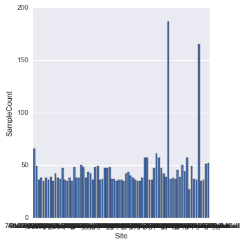

```python
sns.factorplot(x='Site', y='SampleCount', data=rkd, kind='bar')
```

Again, the text here is not necessary, but we can get an idea of how frequently different sites are sampled (and that there are some clear outliers). $$$$ Now lets look at the frequently sampled (more than 50 times):

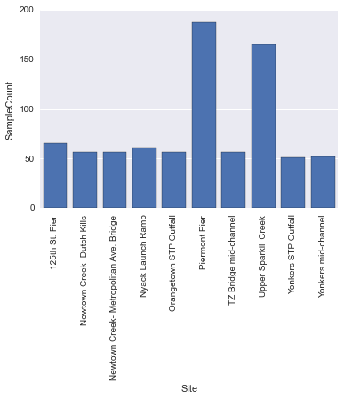

```python
oftenSampled = bysite.filter(lambda x: x['SampleCount'] > 50)
sns.barplot(x='Site', y='SampleCount', data=oftenSampled)
plt.xticks(rotation=90)
```

Piermont Pier and Upper Sparkill creek clearly have significantly more samples than any of the others (and are outliers), but there are still some that are sample much more often.

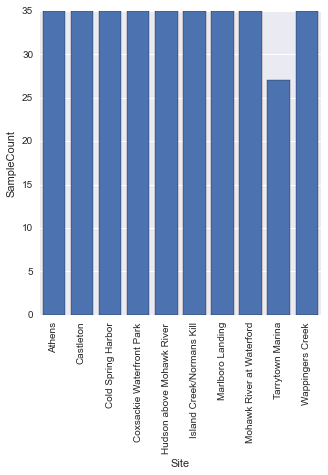

```python
seldomSampled = bysite.filter(lambda x: x['SampleCount'] <= 35)
sns.factorplot(x='Site', y='SampleCount', data=seldomSampled, kind='bar')
plt.xticks(rotation=90)
```

35 seems like a floor except for Tarrytown Marina, which has been sampled less than thirty times).$$$ We now know the max is close to 200, and the minimum is close to 30.$$$ Now lets find out which sites go the longest between samples:

```python
allsites = list(set(rkd['Site']))
```

```python
datesMaxes = []
for i in range(len(allsites)):
    currsite = rkd[rkd['Site'] == allsites[i]].sort(columns='Date')
    rowiterator = currsite.iterrows()
    datesl = []
    siteMax = datetime.timedelta(days=0)
    for j, row in rowiterator:
        datesl.append(row['Date'])
    for j in range(len(datesl) - 1):
        if -1 * (datesl[j] - datesl[j+1]) > siteMax:
            siteMax = -1 * (datesl[j] - datesl[j+1])
    temp = [allsites[i], siteMax]
    datesMaxes.append(temp)
dateMaxes = ps.DataFrame(datesMaxes)
dateMaxes.columns = ['Site', 'MaxDays']
```

```python
dateMaxes
highDays = dateMaxes[dateMaxes['MaxDays'] > np.timedelta64(250, 'D')]
```

```python
highDays
```

|  | Site | MaxDays |
| --- | --- | --- |
| 2 | Yonkers STP Outfall | 256 days |
| 4 | 79th St. mid-channel | 256 days |
| 6 | Cedar Pond Brook | 254 days |
| 7 | Newtown Creek- Dutch Kills | 256 days |
| 9 | Furnace Brook | 254 days |
| 12 | GW Bridge mid-channel | 256 days |
| 13 | East River mid-channel at Roosevelt Is. | 256 days |
| 22 | North River STP at 145th | 256 days |
| 24 | Harlem River- Willis Ave. Bridge | 256 days |
| 31 | Croton Point Beach | 254 days |
| 36 | Gowanus Canal | 281 days |
| 37 | Stony Point mid-channel | 254 days |
| 41 | Tarrytown Marina | 334 days |
| 42 | The Battery mid-channel | 256 days |
| 44 | Ossining Beach | 254 days |
| 51 | 125th St. Pier | 291 days |
| 52 | Saw Mill River | 256 days |
| 54 | Harlem River- Washington Bridge | 256 days |
| 57 | East River mid-channel at 23rd St. | 256 days |
| 58 | Newtown Creek- Metropolitan Ave. Bridge | 256 days |
| 60 | Haverstraw Bay mid-channel | 254 days |
| 62 | Upper Sparkill Creek | 280 days |
| 64 | Yonkers mid-channel | 256 days |
| 66 | Orangetown STP Outfall | 253 days |
| 74 | Peekskill Riverfront Green Park | 254 days |

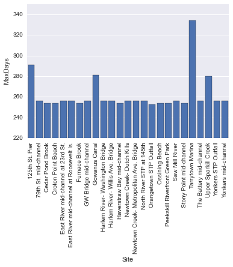

```python
g = sns.barplot(highDays['Site'], highDays['MaxDays'].astype('timedelta64[D]'))
g.set(ylim=(220, None))
plt.xticks(rotation=90)
```

There are clearly some sites that are sampled significantly less often than others, especially the Tarrytown Marina (which is insurprising, given its low overall sample rate) but also the Gowanus Canal, which means that the fact that it has the highest mean is not necessarily reflective (it may only have been studied on bad days).

# 3

Rain and water quality

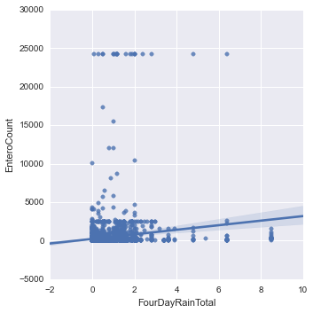

```python
sns.lmplot(y='EnteroCount', x='FourDayRainTotal', data=rkd)
```

We can see that it seems that the more rain there is, the higher the mean Entero Count is (possibly because of the runoff created by the water). Let's use our oftenSampled data set to compare.

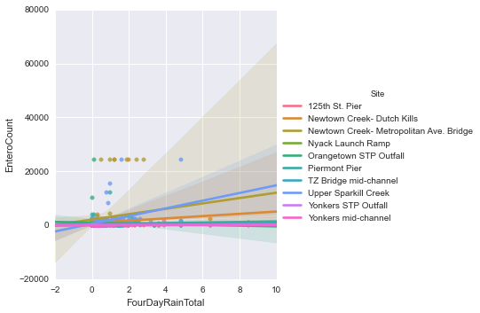

```python
sns.lmplot(y='EnteroCount', x='FourDayRainTotal', hue='Site', data=oftenSampled)
```

We can see that the more it rains, the more Entero we generall encounter (although at some sites it's less). In the ones it's slight less at, this is likely because there is no fecal matter to run off, and thus the water is just diluted by the rain.

```python
rkd['FourDayRainTotal'].describe()
```

```
count    3397.000000
mean        0.568001
std         1.000387
min         0.000000
25%         0.000000
50%         0.200000
75%         0.700000
max         8.500000
dtype: float64
```

```python
lotsofrain = bysite.filter(lambda x: x['FourDayRainTotal'] >= 1.57)
lotrset = set(lotsofrain['Site'])
```

```python
littlerain = bysite.filter(lambda x: x['FourDayRainTotal'] == 0)
litrset = set(littlerain['Site'])
```

Those with a lot of rain (more than a full standard deviation above the mean):

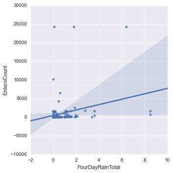

```python
lotrall = rkd[rkd['Site'].isin(lotrset)]
sns.lmplot(y='EnteroCount', x='FourDayRainTotal', data=lotrall)
```

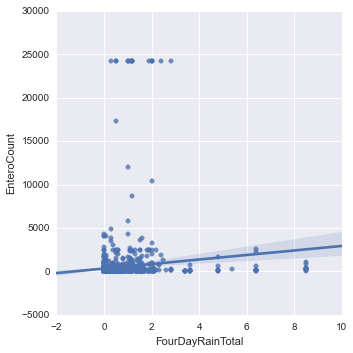

```python
litrall = rkd[rkd['Site'].isin(litrset)]
sns.lmplot(y='EnteroCount', x='FourDayRainTotal', data=litrall)
```